# Simulating thermal environments to understand distributions

2026-04-07

```r
# packages
library(tidyverse)
library(kableExtra)
library(PearsonDS)
```

## Context

I am interested in defining a distribution that can characterize thermal regimes that change over time. I do not think that a normal distribution is the appropriate distribution to use in most cases as by the cyclical nature of temperature changes, the distribution of temperatures is likely to be either bimodal or heavily skewed.

## Define function for temperature fluctuation

Based on a quick as to Gemini, I can define a simple function to simulate temperature fluctuations over a given period of time following the function below:

$$T(t) = T_{\text{mean}} + A \cdot
\sin\left(\frac{2\pi}{t_{\text{max}}}(t - \phi)\right)$$

Where $T(t)$ is the temperature at time $t$, $T_{\text{mean}}$ is the mean daily temperature, $A$ is the amplitude of the temperature fluctuation, $t_{max}$ is the maximum value within the period considered and $\phi$ is the phase shift that determines when the peak temperature occurs during the day. Below is the function in R with an example usage case:

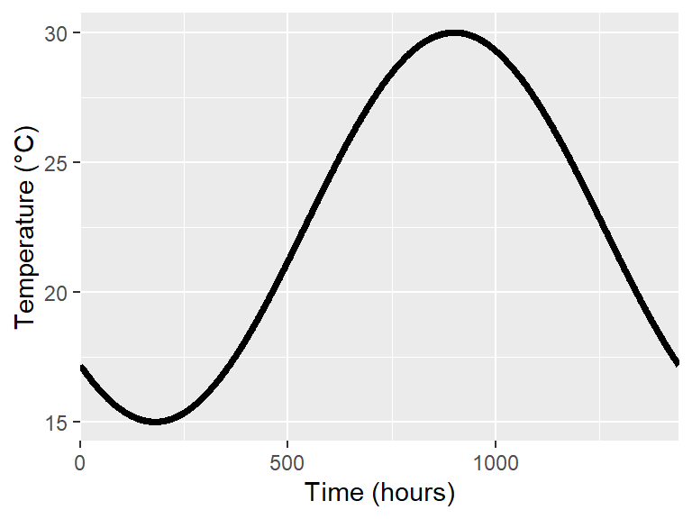

```r
# define function
temp_fluct <- function(t, t_max, t_mean, amp, peak) {
  t_mean + amp * sin((2 * pi / t_max) * (t - peak + t_max / 4))
}

# example usage over a 24 hour period by minutes
tibble(
  time = seq(0, 24 * 60, by = 1),
  temp = temp_fluct(
    time, t_max = 24 * 60, t_mean = 22.5, amp = 7.5, peak = 15 * 60
  )
) |>
  ggplot(aes(x = time, y = temp)) +
  geom_line(linewidth = 1.25) +
  scale_x_continuous(expand = c(0, 0)) +
  labs(x = "Time (hours)", y = "Temperature (°C)")
```

Easy enough. Here I could also add a bit of noise by adding an auto-correlated error term to the function, or divide fluctuations between day-time and night-time periods but I will save that for another post.

Here is the crux of the problem. Let’s visualize the distribution of temperatures over a day overlaid over the temperature fluctuation over time:

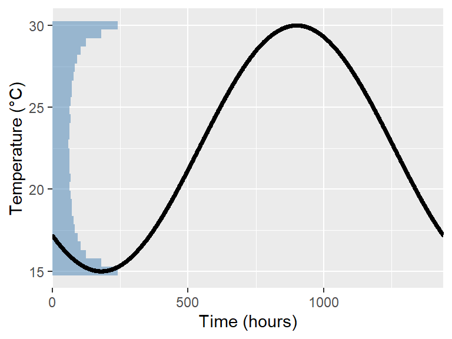

```r
tibble(
  time = seq(0, 24 * 60, by = 1),
  temp = temp_fluct(
    time, t_max = 24 * 60, t_mean = 22.5, amp = 7.5, peak = 15 * 60
  )
) |>
  ggplot(aes(y = temp)) +
  geom_histogram(
    aes(x = after_stat(count) * 2), # exaggerating counts a bit for viz.
    fill = "steelblue", alpha = 0.5
  ) +
  geom_line(aes(x = time), linewidth = 1.25) +
  scale_x_continuous(expand = c(0, 0)) +
  labs(x = "Time (hours)", y = "Temperature (°C)")
```

The distribution over a day **is totally bimodal**. Even if you just take day-time and night-time periods the distributions are extremely skewed. This is a problem for many of the commonly used distributions in statistics that assume unimodality and symmetry.

## Defining a function for *body* temperature fluctuations

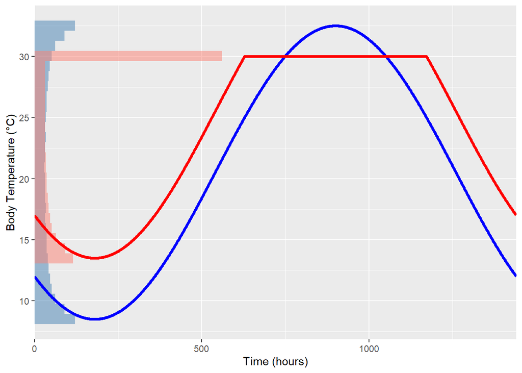

```r
body_temp_fluct <- function(t, t_max, t_mean, amp, peak, t_var, t_opt, ct_min, ct_max) { # nolint

  env_temp <- temp_fluct(t, t_max, t_mean, amp, peak) # nolint

  dplyr::case_when(
    env_temp <= ct_min - t_var ~ env_temp,
    env_temp >= ct_min - t_var & env_temp < t_opt - t_var ~ env_temp + t_var,
    env_temp >= t_opt - t_var & env_temp <= t_opt + t_var ~ t_opt,
    env_temp > t_opt + t_var & env_temp < ct_max + t_var ~ env_temp - t_var,
    env_temp >= ct_max + t_var ~ env_temp
  )

}

# test function
t_mean_general <- 20.5
amp_general <- 12
body_temps <- body_temp_fluct(
  t = seq(0, 24 * 60, by = 1),
  t_max = 24 * 60,
  t_mean = t_mean_general,
  amp = amp_general,
  peak = 15 * 60,
  t_var = 5,
  t_opt = 30,
  ct_min = 10,
  ct_max = 40
)
ambient_temps <- temp_fluct(
  t = seq(0, 24 * 60, by = 1),
  t_max = 24 * 60,
  t_mean = t_mean_general,
  amp = amp_general,
  peak = 15 * 60
)
tibble(
  time = seq(0, 24 * 60, by = 1),
  ambient_temp = ambient_temps,
  body_temp = body_temps
) |>
  ggplot() +
  geom_histogram(
    aes(y = ambient_temp, x = after_stat(count)),
    fill = "steelblue", alpha = 0.5
  ) +
  geom_histogram(
    aes(y = body_temp, x = after_stat(count)),
    fill = "salmon", alpha = 0.5
  ) +
  geom_line(aes(x = time, y = ambient_temp), linewidth = 1.25, color = "blue") +
  geom_line(aes(x = time, y = body_temp), linewidth = 1.25, color = "red") +
  scale_x_continuous(expand = c(0, 0)) +
  labs(x = "Time (hours)", y = "Body Temperature (°C)")
```

## Mapping distribution of temperatures over a year

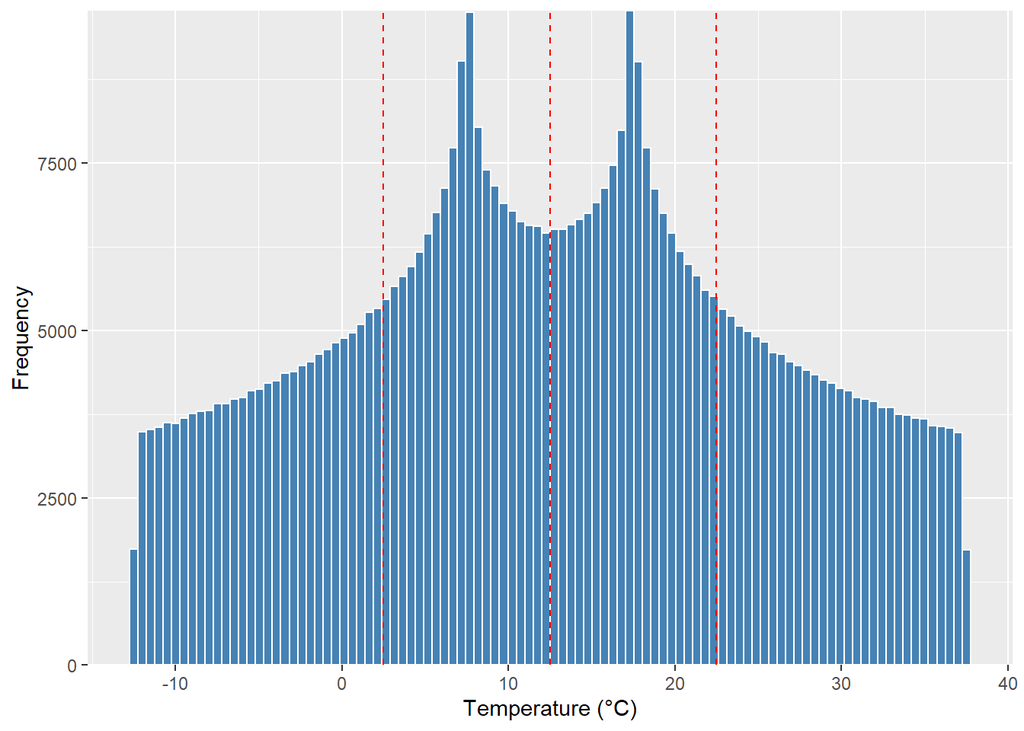

```r
# define parameters
t_max_doy <- 365
t_mean_doy <- 12.5
amp_doy <- 10
peak_doy <- round(365 * (15 / 24))
amp_hour <- 15
peak_hour <- 15 * 60

# define holder data frame
temp_data <- tibble(
  doy = rep(1:365, each = 1440), # day of year
  mod = rep(1:1440, times = 365), # hour of day
  mean_doy_temp = temp_fluct(doy, t_max_doy, t_mean_doy, amp_doy, peak_doy),
  mean_hour_temp = temp_fluct(mod, 1440, mean_doy_temp, amp_hour, peak_hour),
  cum_time = (doy - 1) * 1440 + mod, # cumulative time in minutes
)

# plot distribution of temperatures
temp_data |>
  ggplot(aes(x = mean_hour_temp)) +
  geom_histogram(bins = 100, fill = "steelblue", color = "white") +
  geom_vline(xintercept = t_mean_doy, linetype = "dashed", color = "red") +
  geom_vline(
    xintercept = t_mean_doy + amp_doy, linetype = "dashed", color = "red"
  ) +
  geom_vline(
    xintercept = t_mean_doy - amp_doy, linetype = "dashed", color = "red"
  ) +
  labs(x = "Temperature (°C)", y = "Frequency") +
  scale_y_continuous(expand = c(0, 0))
```